# Kernel density estimation in R spatial

12 August, 2021

Download this notebook.

## Data

The data for this one are some point data (Airbnb listings from [here](http://insideairbnb.com/new-zealand/)) and some polygon data (NZ census Statistical Area 2 data).

## Packages

This requires a surprising number of moving parts (at least the way I did it):

```r
library(sf)
library(tmap)
library(spatstat)
library(maptools)
library(raster)
library(RColorBrewer) # because default raster colours are horrible
library(dplyr)
```

Optionally web maps are nice…

```r
# tmap_mode("view")
```

Load the data:

```r
polys <- st_read("sa2.gpkg")
pts <- st_read("abb.gpkg")
```

## Getting ready for the analysis

We need some bounding box info to manage the density estimation resolution

```r
bb <- st_bbox(polys)
cellsize <- 100
height <- (bb$ymax - bb$ymin) / cellsize
width <- (bb$xmax - bb$xmin) / cellsize
```

### A fallback sanity check

To give us an alternative view of the data, let’s just count points in polygons

```r
polys$n <- polys %>%
  st_contains(pts) %>%
  lengths()
```

And map the result

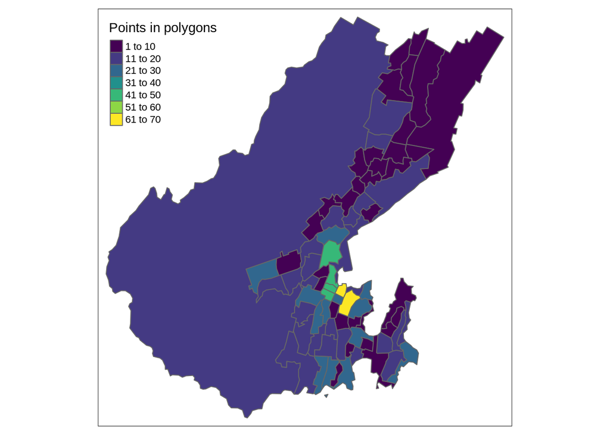

```r
tm_shape(polys) +
  tm_polygons(col = "n", palette = "viridis", title = "Points in polygons")
```

## `spatstat` for density estimation

The best way I know to do density estimation in the R ecosystem is using the [`spatstat`] library’s specialisation of base *R*’s `density` function. That means converting the point data to a `spatstat` planar point pattern (`ppp`) object

```r
pts.ppp <- pts$geom %>%
  as("Spatial") %>% # we need to convert to sp as a bridge to spatstat
  as.ppp()          # and this is what we need maptools for...
```

A point pattern also needs a ‘window’, which we’ll make from the polygons.

```r
pts.ppp$window <- polys %>%
  st_union() %>%       # combine all the polygons into a single shape
  as("Spatial") %>%    # convert to sp
  as.owin()            # convert to spatstat owin - again maptools...
```

## Now the kernel density

Here we specify the size of the raster we want with `dimyx` (note the order, y then x) using the number of pixels (`height` and `width`) we calculated earlier. We can convert this directly to a raster, but have to supply a CRS which we pull from the original points input dataset. At the time of writing (August 2021) you’ll get a complaint about the New Zealand Geodetic Datum 2000 because recent changes in how projections and datums are handled are still working themselves out.

```r
kde <- density(pts.ppp, sigma = 200, dimyx = c(height, width)) %>%
  raster(crs = st_crs(pts)$wkt) # a ppp has no CRS information
```

We can map this - the default colour ramp in `raster` is horrible, so use `RColorBrewer::brewer.pal` to get something nicer.

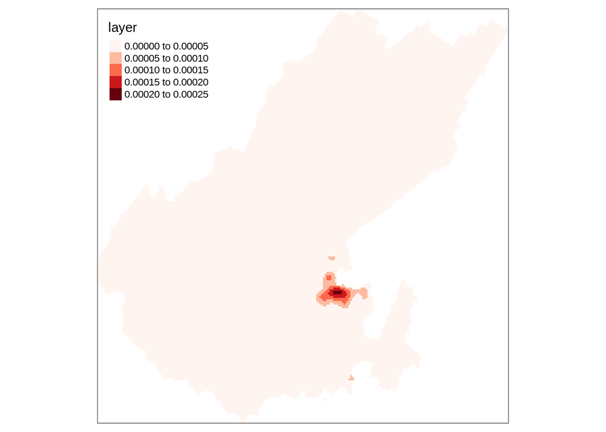

```r
tm_shape(kde) +
  tm_raster(palette = brewer.pal(9, "Reds"))
```

## Aggregate the density surface pixels to polygons

This isn’t at all necessary, but is also useful to know. This is also a relatively slow operation. Note that we add together the density estimates in the pixels contained by each polygon.

```r
summed_densities <- raster::extract(kde, polys, fun = sum)
```

Append this to the polygons and rescale so the result is an estimate of the original count. We multiply by `cellsize^2` because each cell contains an estimate of the per sq metre (in this case, but per sq distance unit in general) density, so multiplying by the area of the cells gives an estimated count.

```r
polys$estimated_count = summed_densities[, 1] * cellsize ^ 2
```

And now we can make another map

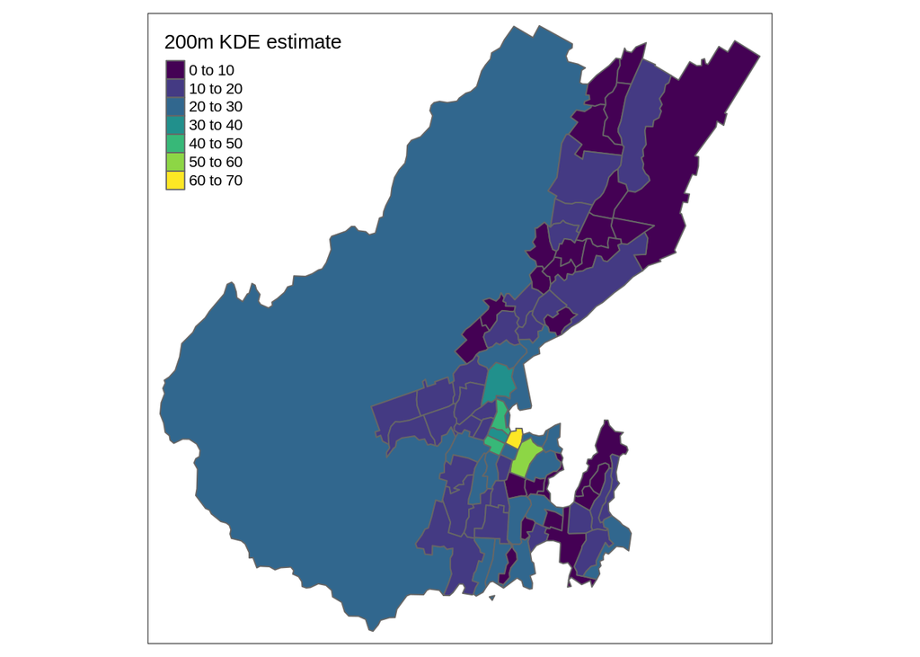

```r
tm_shape(polys) +
  tm_polygons(col = "estimated_count", palette = "viridis", title = "200m KDE estimate")
```

Back to the junkyard